# Estudio sobre la empleabilidad en Lima Metropolitana en el primer trimestre del año 2021

#### Gráfica de error regresión

$e=y_i-(29.57x_i+105.37)$ $\\\\ ;\ x_{i}\in [1; 39]$

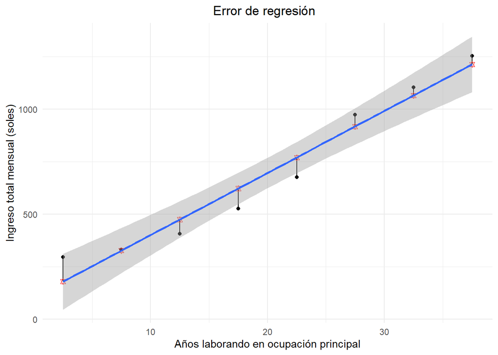

#### Calculando el error de regresión tomando valores de la muestra

Para hallar un error promedio de regresión se tomaron diez observaciones de la muestra aleatoriamente. De dichas muestras se tomaron los años laborando en la ocupación principal de cada encuestado y este dato se evaluó en la función de regresión calculada. Luego, se comparó el valor obtenido con el ingreso total real de dicho encuestado. Finalmente, el error promedio de regresión es: 390.19.

#### Conclusiones

- A partir del estudio realizado se han podido responder la mayor parte de las preguntas planteadas en un inicio, esto fue gracias a los análisis explorativo y descriptivo. En ese sentido, los diagramas estadísticos permitieron un correcto análisis y buenas observaciones acerca de las variables.
- En cuanto al análisis inferencial, se han podido identificar dependencia entre variables numéricas. Sin embargo, la mayor parte de estas cumplen en un intervalo determinado, por lo que muestran el comportamiento de una parte de la muestra. En ese sentido, las predicciones que se pueden realizar están sujetas al intervalo en donde cumplen dichas dependencias.
- En cuanto a los patrones identificados, hemos podido determinar que la edad donde se suele ganar un mayor sueldo aproximadamente a los 45 años, mientras que al comienzo y al final de la vida laboral se suele ganar debido a la experiencia laboral.
- En cuanto a los indicadores de empleabilidad, se identificó al ingreso total mensual de los encuestados como el más representativo. Además se especula la influencia de variables como años laborando y edad.
- Por último, a partir del análisis inferencial se puede afirmar que la experiencia laboral implica un aumento del ingreso mensual, por lo que las recomendaciones para la población para esta situación es tratar de buscar un empleo estable, que les permita ganar experiencia. Además, es recomendable que, como mínimo, se complete la educación secundaria, ya que a través de los gráficos se aprecia que es un factor relevante para poder laborar en una ocupación.

### Bibliografía

| **Tema** | **Link** |
| --- | --- |
| Base de datos | [Encuesta Permanente de Empleo (EPE) 2021 Trimestre Móvil (enero-febrero-marzo) - [Instituto Nacional de Estadística e Informática - INEI]](http://iinei.inei.gob.pe/microdatos/) |
| Ficha técnica | [Encuesta Permanente de Empleo Lima Metropolitana - Ficha Técnica 2021](http://iinei.inei.gob.pe/iinei/srienaho/descarga/SPSS/735-Modulo76.zip) |
| Diccionario de datos | [Encuesta Permanente de Empleo - Diccionario de Datos (Marzo 2001 - Marzo 2021)](http://iinei.inei.gob.pe/iinei/srienaho/descarga/SPSS/735-Modulo76.zip) |
| Cuestionario | [Encuesta Permanente de Empleo en Lima Metropolitana -2021 - Cuestionario Confidencial](http://iinei.inei.gob.pe/iinei/srienaho/descarga/SPSS/735-Modulo76.zip) |